# Mini-Project - Global Temperatures

Jordan Menter & Lizzie Kumar

June 7, 2016

### Introduction

In this report, we analyze trends in average monthly global temperature from 1881 to 2012. Our [data](http://data.giss.nasa.gov/gistemp/tabledata_v3/GLB.Ts+dSST.txt) comes from the NASA Goddard Institute for Space Studies. Note that this data is measured in 0.01 degrees Celsius - for our analyses, we convert it to absolute temperature in Fahrenheit.

### Monthly Mean Global Temperatures

We begin by finding the mean global temperature for each month. This data is displayed in the following table:

57.1581364, 57.1826818, 57.2040909, 57.1661818, 57.1480455, 57.1273182, 57.1784545, 57.1724545, 57.185, 57.2043636, 57.191, 57.1475

127, 118, 122, 130, 130, 118, 131, 131, 125, 125, 130, 126

We complete the same analysis for the lowest average global temperature of each month, shown below.

13, 25, 31, 29, 37, 29, 32, 32, 32, 32, 30, 36

Notice that the dates at which the highest average global temperatures occur are consistently more recent than those at which the lowest average global temperatures occur.

### Visualizing Monthly Average Global Temperatures

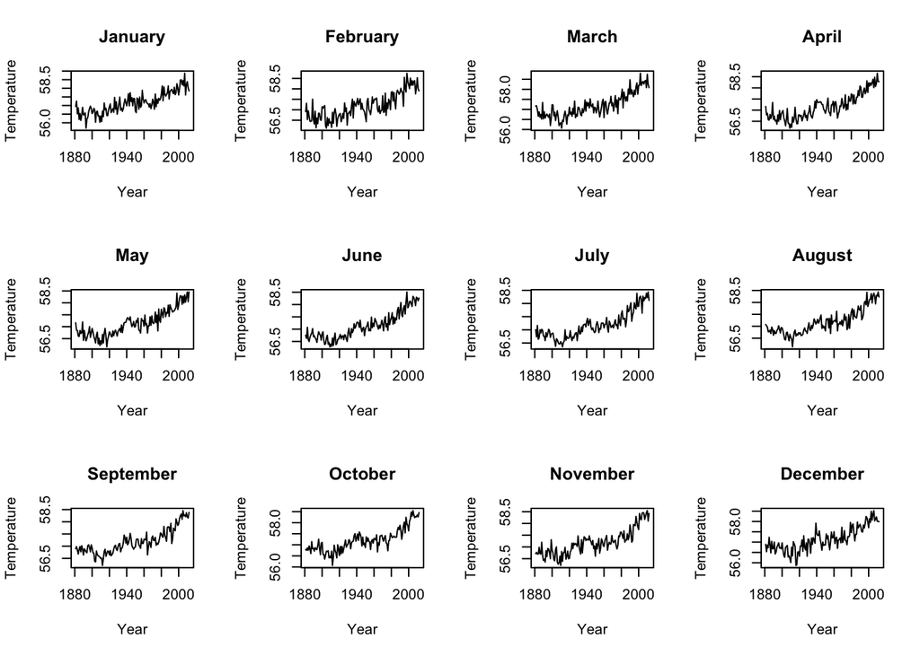

We see that each month has a consistent warming trend over the course of the years under consideration.

### Visualizing Average Annual Temperatures, 1881 - 2012

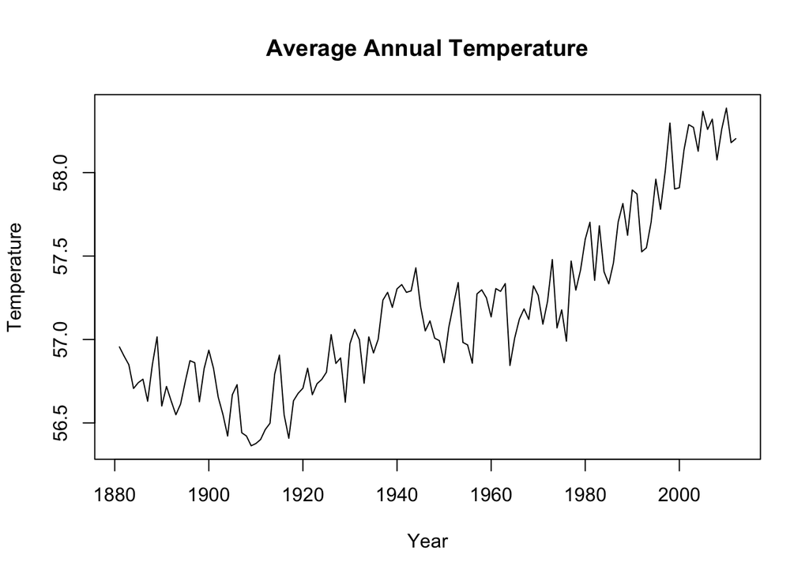

### Monthly Average Temperatures in the 2000s

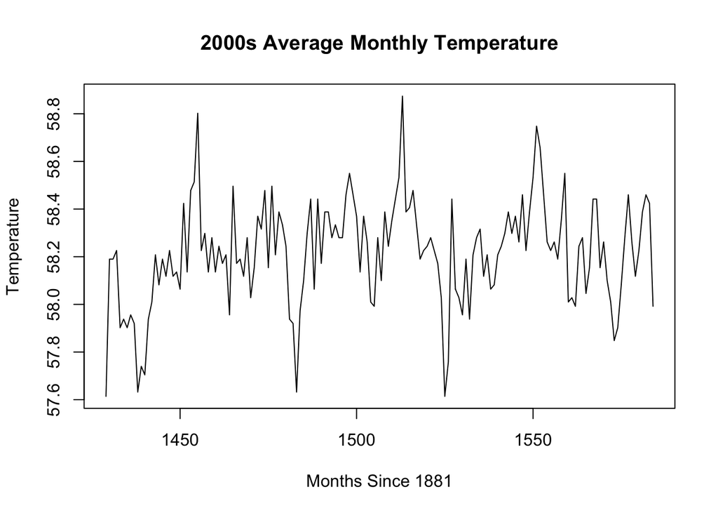

When considering only the years from 2000 to 2012, it is difficult to discern a consistent warming or cooling trend. The data appears rather noisy.

### Monthly Average Temperatures in the 1990s

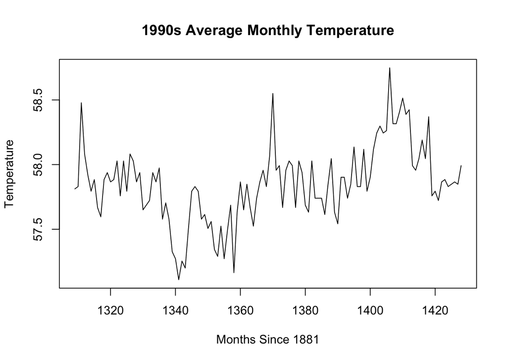

### Monthly Average Temperatures in the 1890s

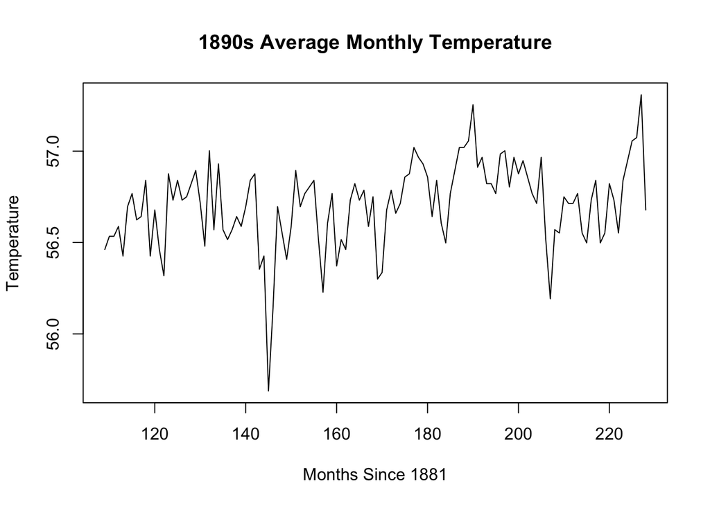

The mean temperature of this decade is 56.70485.

### Observing Warming Trends

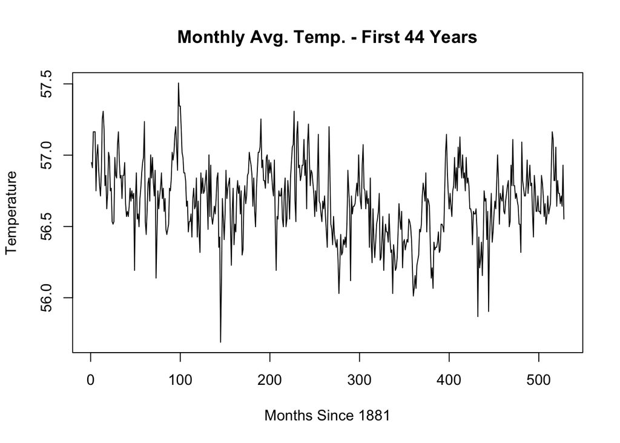

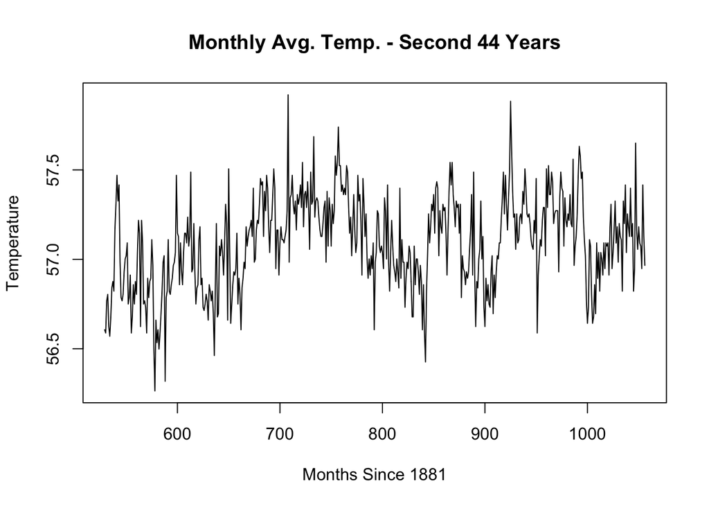

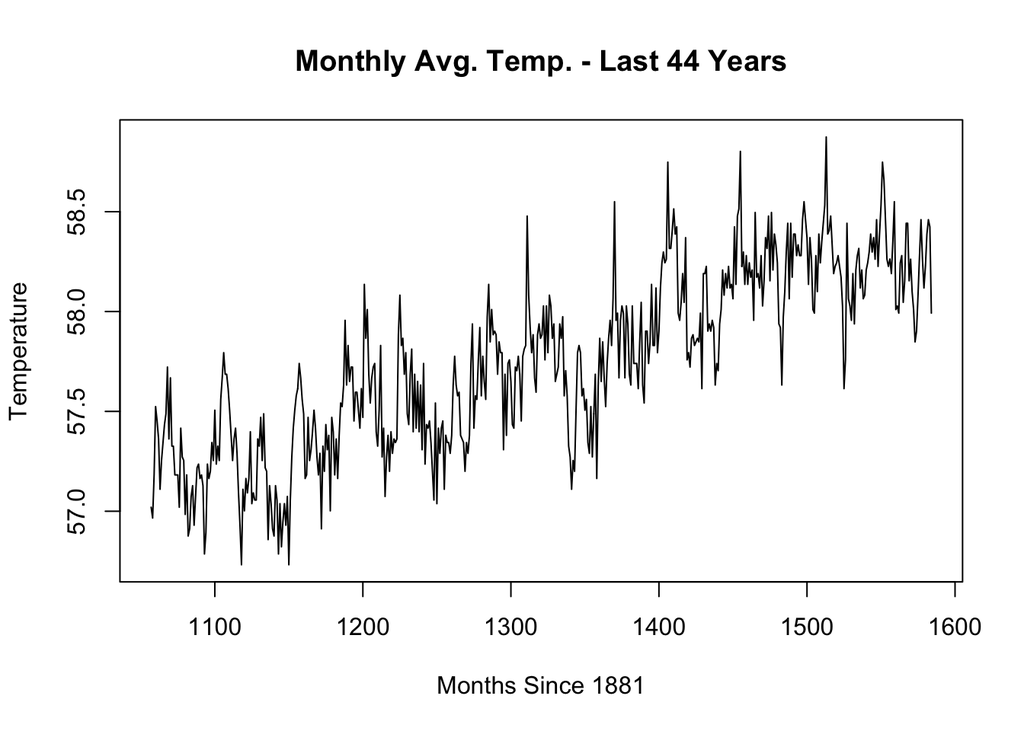

The mean temperature of the first 44 years is 56.6789205. Of the three periods considered here, it is easiest to observe a consistent warming trend in the last 44 years.